# Reproducible Research: Peer Assessment 1

EMSRES

2026-06-04

## Loading and preprocessing the data

First, the working directory is changed and the data is loaded:

```r
setwd("D:/Eva/PhD/Courses/ReproducibleResearch/Assignment1")
data <- read.csv("activity.csv")
```

## What is mean total number of steps taken per day?

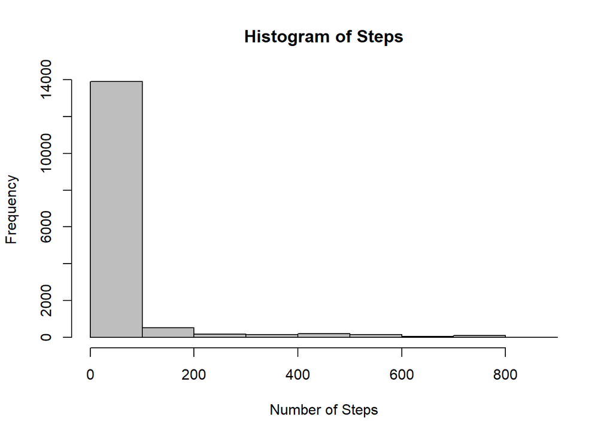

```r
StepsPerDay <- aggregate(. ~ date, data = data, FUN = sum)

StepsHistogram <- hist(
    data$steps,
    main = "Histogram of Steps",      # Title
    xlab = "Number of Steps",         # X-axis label
    ylab = "Frequency",               # Y-axis label
    col = "grey",                     # Fill color
    border = "black",                 # Border color
    breaks = 10                       # Number of bins
)
```

```r
meanStepsPerDay <- mean(StepsPerDay$steps)
medianStepsPerDay <- median(StepsPerDay$steps)
```

Mean and median of the total number of steps are:

```
## [1] "Mean:  10766.1886792453"
```

```
## [1] "Median:  10765"
```

## What is the average daily activity pattern?

To evaluate the average daily activity pattern, a sub-dataset is generated containing the steps per interval and the steps are averaged for each 5-minute interval across all days:

```r
library(dplyr)
dataNoDate <- data %>% select(-date)
StepsPerInterval <- aggregate(. ~ interval, data = dataNoDate, FUN = mean)
```

Afterwards, a time series plot is generated:

```r
library(ggplot2)
library(lubridate)
StepsTimeSeries <- ggplot(StepsPerInterval, aes(x = interval, y = steps)) +
    geom_line(color = "steelblue") +
    labs(
        title = "Time Series Plot",
        x = "Time interval",
        y = "Mean steps"
    )
```

The daily activity pattern looks on average as follows:

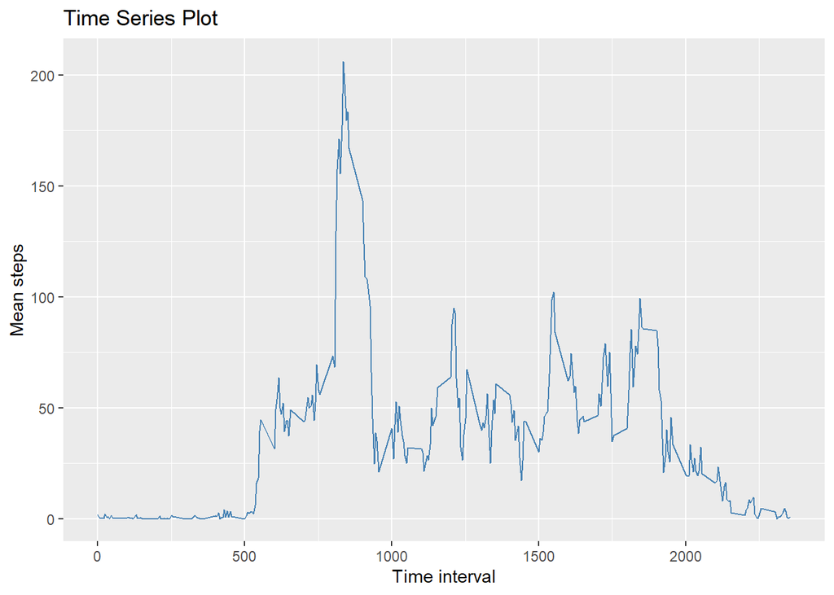

The maximum number of steps on average is determined using the following code:

```r
max_point <- StepsPerInterval %>%
    filter(steps == max(steps, na.rm = TRUE))
```

resulting in the following result:

```
## [1] "The maximum number of steps is on average taken in interval 835"
```

## Imputing missing values

Before imputing missing values, first, the total number of missing values in the dataset is calculated as follows:

```r
TotalMissingValues <- sum(is.na(data))
```

The total number of missing values is:

```
## [1] 2304
```

```r
library(dplyr)
dataImputed <- data %>% mutate(across(where(is.numeric), ~replace(., is.na(.), mean(., na.rm=TRUE))))
```

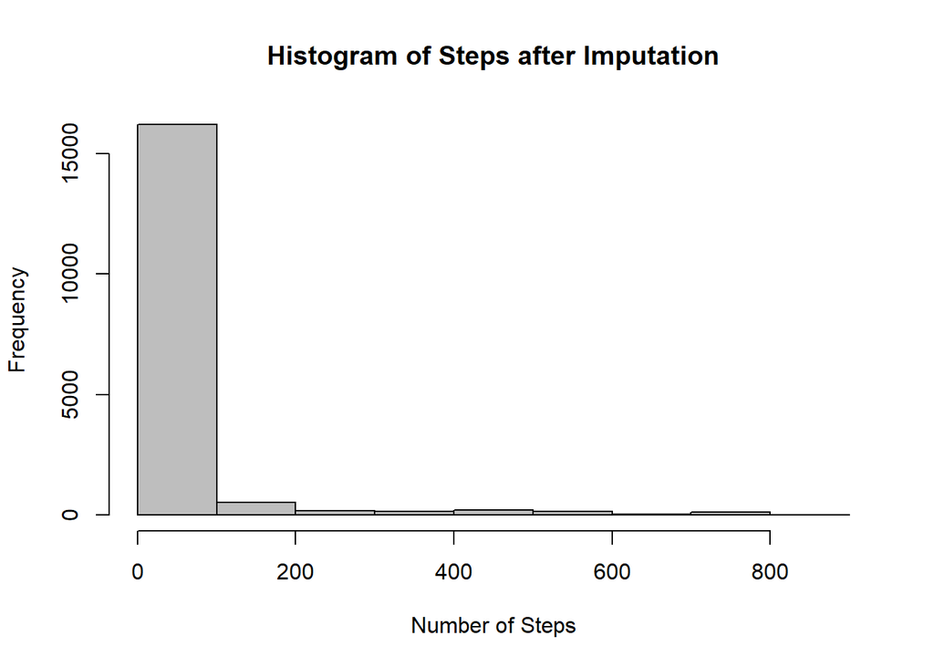

```r
StepsHistogramImputed <- hist(
    dataImputed$steps,
    main = "Histogram of Steps after Imputation",   # Title
    xlab = "Number of Steps",                       # X-axis label
    ylab = "Frequency",                             # Y-axis label
    col = "grey",                                   # Fill color
    border = "black",                               # Border color
    breaks = 10                                     # Number of bins
)
```

And the mean and median total number of steps taken per day is calculated and reported:

```r
StepsPerDayImputed <- aggregate(. ~ date, data = dataImputed, FUN = sum)
meanStepsPerDayAfterImputation <- mean(StepsPerDayImputed$steps)
medianStepsPerDayAfterImputation <- median(StepsPerDayImputed$steps)
```

Mean and median of the total number of steps are:

```
## [1] "Mean: 10766.1886792453"
```

```
## [1] "Median: 10766.1886792453"
```

In comparison, without imputation the following mean and median were obtained:

```
## [1] "Mean: 10766.1886792453"
```

```
## [1] "Median: 10765"
```

Accordingly, the obtained mean stayed the same while the median differs depending on whether or not missing values are imputed.

## Are there differences in activity patterns between weekdays and weekends?

To determine differences in activity patterns between weekdays and weekends, a new factor variable is generated categorizing each date based on whether it is a weekday or a weekend day:

```r
data$date <- as.Date(data$date, format = "%Y-%m-%d")
data$weekday <- weekdays(data$date, abbreviate = FALSE)
data$weekdayCategory <-
  ifelse(weekdays(data$date) %in% c("Samstag", "Sonntag"), "Weekend", "Weekday")
```

Afterwards, the average number of steps is determined, averaged across all weekday days or weekend days:

```r
StepsPerIntervalWeektime <- data %>%
  group_by(weekdayCategory, interval) %>%
  summarise(
    mean_steps = mean(steps, na.rm = TRUE),
    first_interval = first(interval),
    .groups = "drop_last"
  )
```

And a time series plot is generated:

```r
TimeSeriesWeektime <- ggplot(StepsPerIntervalWeektime, aes(x = interval, y = mean_steps)) +
    geom_line(color = "steelblue") +
    facet_wrap(~ weekdayCategory, nrow = 2, scales = "fixed") +
    labs(
        title = "Panel Time Series Plot for Weekdays versus Weekend Days",
        x = "Time interval",
        y = "Mean steps"
    )
```

The panel time series plot looks as follows:

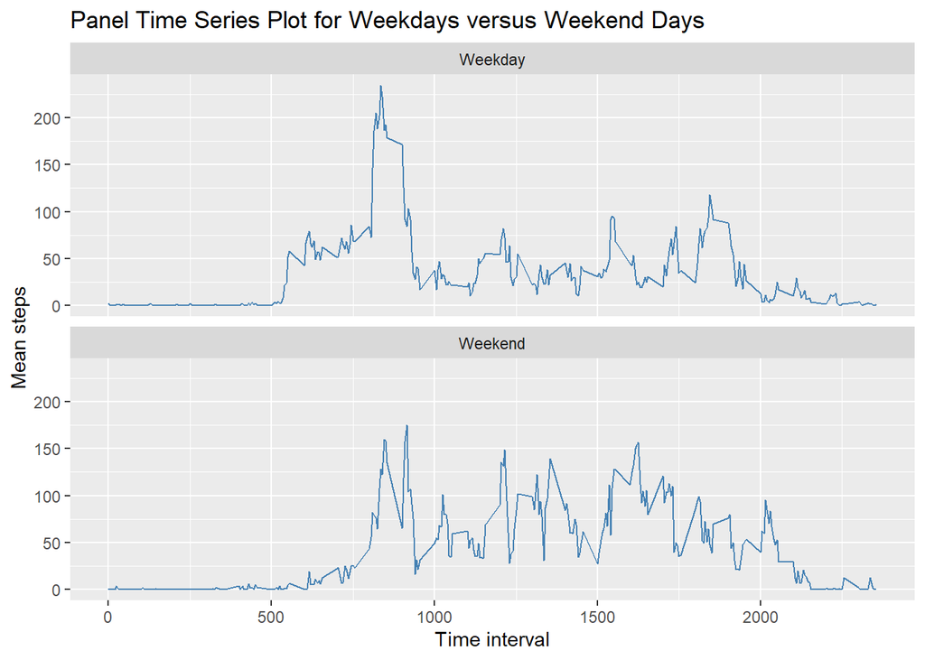